# Final_Project_Regression_D

Binghan Zheng

4/1/2022

# SetUp

#Libraries

```r
library(tidyverse)
library(fastDummies)
library(caret)
```

#Preparing the Data

```r
df_all <- readr::read_csv("final_project_train.csv", col_names = TRUE)
df_all <- dummy_cols(df_all, select_columns = 'region')
df_all <- dummy_cols(df_all, select_columns = 'customer')
df_all$log_response <- log(df_all$response)

df_all %>% head()
```

```
## # A tibble: 6 x 51
##   rowid region customer xb_01 xb_02 xb_03 xn_01 xn_02 xn_03 xa_01 xa_02 xa_03
##   <dbl> <chr>  <chr>    <dbl> <dbl> <dbl> <dbl> <dbl> <dbl> <dbl> <dbl> <dbl>
## 1     1 XX     B         4        4     4 3         3     3 12       12    12
## 2     3 XX     B         1        1     1 2         2     2  3        3     3
## 3     4 XX     B         2        2     2 2         4     0  9        9     9
## 4     5 XX     B         2.52    11    -6 1.53      9    -3  7.08    29    -7
## 5     8 XX     B         2.55     6    -1 0.839     3    -4  6.45    17    -2
## 6     9 XX     B         3.07     6     1 1.86      8    -2  6.86    18     2
## # ... with 39 more variables: xb_04 <dbl>, xb_05 <dbl>, xb_06 <dbl>,
## #   xb_07 <dbl>, xb_08 <dbl>, xn_04 <dbl>, xn_05 <dbl>, xn_06 <dbl>,
## #   xn_07 <dbl>, xn_08 <dbl>, xa_04 <dbl>, xa_05 <dbl>, xa_06 <dbl>,
## #   xa_07 <dbl>, xa_08 <dbl>, xw_01 <dbl>, xw_02 <dbl>, xw_03 <dbl>,
## #   xs_01 <dbl>, xs_02 <dbl>, xs_03 <dbl>, xs_04 <dbl>, xs_05 <dbl>,
## #   xs_06 <dbl>, response <dbl>, outcome <chr>, region_XX <int>,
## #   region_YY <int>, region_ZZ <int>, customer_A <int>, customer_B <int>, ...
```

```r
set.seed(12345)
my_ctrl <- caret::trainControl(method = "repeatedcv",
                               number = 5,
                               repeats = 3,
                               savePredictions = TRUE)
my_metric <- "RMSE"
```

##LINEAR

#Model 1: Categorical and Continuous Additive

```r
set.seed(2033)
mod1 <- train(log_response ~ region_XX + region_YY + region_ZZ +
              customer_A + customer_B + customer_D + customer_E + customer_G + customer_K +
              customer_M + customer_Other + customer_Q + xa_01 +
              xa_02 + xa_03 + xa_04 + xa_05 + xa_06 + xa_07 + xa_08 +
              xb_01 + xb_02 +  xb_03 + xb_04 + xb_05 + xb_06 +  xb_07 + xb_08 +
              xs_01 + xs_02 + xs_03 + xs_04 + xs_05 + xs_06 +
              xn_01 + xn_02 + xn_03 + xn_04 + xn_05 + xn_06 + xn_07 + xn_08 +
              xw_01 + xw_02 + xw_03,
                    data = df_all,
                    method = "lm",
                    metric = my_metric,
                    preProcess = c("center" , "scale"),
                    trControl = my_ctrl)
```

#Model 2: Linear Pairwise of Continuous w/ Additive Categorical

```r
set.seed(2033)
mod2<- train(log_response ~ (xa_01 + xa_02 + xa_03 + xa_04 + xa_05 + xa_06 + xa_07 +
                     xa_08 + xb_01 + xb_02 +  xb_03 + xb_04 + xb_05 + xb_06 +  xb_07 + xb_08 +
                     xs_01 + xs_02 + xs_03 + xs_04 + xs_05 + xs_06 +
                     xn_01 + xn_02 + xn_03 + xn_04 + xn_05 + xn_06 + xn_07 + xn_08 +
                     xw_01 + xw_02 + xw_03)^2 + region_XX + region_YY + region_ZZ +
                     customer_A + customer_B + customer_D + customer_E + customer_G +
                     customer_K + customer_M + customer_Other + customer_Q,
                    data = df_all,
                    method = "lm",
                    metric = my_metric,
                    preProcess = c("center" , "scale"),
                    trControl = my_ctrl)
```

#Model 3: Model A - Model 9

#Model 8 - Splines Interact Customer

```r
mod3 <- train( log_response ~
              (splines::ns(xa_01, 3) + splines::ns(xa_02, 3) +
              splines::ns(xa_03, 3) + splines::ns(xa_04, 3) +
              splines::ns(xa_05, 3) + splines::ns(xa_06, 3) +
              splines::ns(xa_07, 3) + splines::ns(xa_08, 3) +

              splines::ns(xb_01, 3) + splines::ns(xb_02, 3) +
              splines::ns(xb_03, 3) + splines::ns(xb_04, 3) +
              splines::ns(xb_05, 3) + splines::ns(xb_06, 3) +
              splines::ns(xb_07, 3) + splines::ns(xb_08, 3) +

              splines::ns(xs_01, 3) + splines::ns(xs_02, 3) +
              splines::ns(xs_03, 3) + splines::ns(xs_04, 3) +
              splines::ns(xs_05, 3) + splines::ns(xs_06, 3) +

              splines::ns(xn_01, 3) + splines::ns(xn_02, 3) +
              splines::ns(xn_03, 3) + splines::ns(xn_04, 3) +
              splines::ns(xn_05, 3) + splines::ns(xn_06, 3) +
              splines::ns(xn_07, 3) + splines::ns(xn_08, 3) +

              splines::ns(xw_01, 3) + splines::ns(xw_02, 3) +
              splines::ns(xw_03, 3)) *

  (customer_A + customer_B + customer_D + customer_E + customer_G +
  customer_K + customer_M +  customer_Other + customer_Q),
  data = df_all,
  method = "lm",
  metric = my_metric,
  preProcess = c("center" , "scale"),
  trControl = my_ctrl)
```

#Model 4: Model B

```r
#Model 6
set.seed(2033)
mod4<- train(log_response ~ (xa_01 +
              xa_02 + xa_03 + xa_04 + xa_05 + xa_06 + xa_07 + xa_08 +
              xb_01 + xb_02 +  xb_03 + xb_04 + xb_05 + xb_06 +  xb_07 + xb_08 +
              xs_01 + xs_02 + xs_03 + xs_04 + xs_05 + xs_06 +
              xn_01 + xn_02 + xn_03 + xn_04 + xn_05 + xn_06 + xn_07 + xn_08 +
              xw_01 + xw_02 + xw_03)^2,
                    data = df_all,
                    method = "lm",
                    metric = my_metric,
                    preProcess = c("center" , "scale"),
                    trControl = my_ctrl, trace = FALSE)
```

##REGULARIZED REGRESSION W/ ELASTIC NET

#Model 5: Pairwise of Continuous w/ Additive Categorical

```r
mod5 <- train(log_response ~ (xa_01 + xa_02 + xa_03 + xa_04 + xa_05 + xa_06 + xa_07 +
                     xa_08 + xb_01 + xb_02 +  xb_03 + xb_04 + xb_05 + xb_06 +  xb_07 + xb_08 +
                     xs_01 + xs_02 + xs_03 + xs_04 + xs_05 + xs_06 +
                     xn_01 + xn_02 + xn_03 + xn_04 + xn_05 + xn_06 + xn_07 + xn_08 +
                     xw_01 + xw_02 + xw_03)^2 + region_XX + region_YY + region_ZZ +
                     customer_A + customer_B + customer_D + customer_E + customer_G +
                     customer_K + customer_M + customer_Other + customer_Q,
                  data = df_all,
                  method = "glmnet",
                  metric = my_metric,
                  preProcess = c("center", "scale"),
                  trControl = my_ctrl,
              trace = FALSE)
```

#Model 6: More Complex of Our Models

```r
mod6<- train( log_response ~
              (splines::ns(xa_01, 3) + splines::ns(xa_02, 3) +
              splines::ns(xa_03, 3) + splines::ns(xa_04, 3) +
              splines::ns(xa_05, 3) + splines::ns(xa_06, 3) +
              splines::ns(xa_07, 3) + splines::ns(xa_08, 3) +

              splines::ns(xb_01, 3) + splines::ns(xb_02, 3) +
              splines::ns(xb_03, 3) + splines::ns(xb_04, 3) +
              splines::ns(xb_05, 3) + splines::ns(xb_06, 3) +
              splines::ns(xb_07, 3) + splines::ns(xb_08, 3) +

              splines::ns(xs_01, 3) + splines::ns(xs_02, 3) +
              splines::ns(xs_03, 3) + splines::ns(xs_04, 3) +
              splines::ns(xs_05, 3) + splines::ns(xs_06, 3) +

              splines::ns(xn_01, 3) + splines::ns(xn_02, 3) +
              splines::ns(xn_03, 3) + splines::ns(xn_04, 3) +
              splines::ns(xn_05, 3) + splines::ns(xn_06, 3) +
              splines::ns(xn_07, 3) + splines::ns(xn_08, 3) +

              splines::ns(xw_01, 3) + splines::ns(xw_02, 3) +
              splines::ns(xw_03, 3)) *

  (customer_A + customer_B + customer_D + customer_E + customer_G +
  customer_K + customer_M +  customer_Other + customer_Q),
                    data = df_all,
                    method = "glmnet",
                    metric = my_metric,
                    preProcess = c("center" , "scale"),
                    trControl = my_ctrl)
```

#Model 7: Neural Network

```r
mod7<- train(log_response ~ region_XX + region_YY + region_ZZ +
              customer_A + customer_B + customer_D + customer_E + customer_G + customer_K + customer_M +  customer_Other + customer_Q +
              xa_01 + xa_02 + xa_03 + xa_04 + xa_05 + xa_06 + xa_07 + xa_08 +
              xb_01 + xb_02 +  xb_03 + xb_04 + xb_05 + xb_06 +  xb_07 + xb_08 +
              xs_01 + xs_02 + xs_03 + xs_04 + xs_05 + xs_06 +
              xn_01 + xn_02 + xn_03 + xn_04 + xn_05 + xn_06 + xn_07 + xn_08 +
              xw_01 + xw_02 + xw_03,
                    data = df_all,
                    method = "nnet",
                    metric = my_metric,
                    preProcess = c("center" , "scale"),
                    trControl = my_ctrl,
                    trace = FALSE)
```

#Model 8: Random Forest

```r
set.seed(12345)
my_ctrl_rf <- caret::trainControl(method = "repeatedcv",
                               number = 3,

                               savePredictions = TRUE,
                               search = 'random')

mod8 <- train(log_response ~ region_XX + region_YY + region_ZZ +
              customer_A + customer_B + customer_D + customer_E + customer_G + customer_K + customer_M +  customer_Other + customer_Q +
              xa_01 + xa_02 + xa_03 + xa_04 + xa_05 + xa_06 + xa_07 + xa_08 +
              xb_01 + xb_02 +  xb_03 + xb_04 + xb_05 + xb_06 +  xb_07 + xb_08 +
              xs_01 + xs_02 + xs_03 + xs_04 + xs_05 + xs_06 +
              xn_01 + xn_02 + xn_03 + xn_04 + xn_05 + xn_06 + xn_07 + xn_08 +
              xw_01 + xw_02 + xw_03,
                   data = df_all,
                   method = 'rf',
                   metric = my_metric,
                   tuneLength  = 15,
                   trControl = my_ctrl_rf,
              trace = FALSE)
```

#Model 9: Gradient Boosted Tree

```r
fit_xgb <- train(log_response ~ region_XX + region_YY + region_ZZ +
              customer_A + customer_B + customer_D + customer_E + customer_G + customer_K + customer_M +  customer_Other + customer_Q +
              xa_01 + xa_02 + xa_03 + xa_04 + xa_05 + xa_06 + xa_07 + xa_08 +
              xb_01 + xb_02 +  xb_03 + xb_04 + xb_05 + xb_06 +  xb_07 + xb_08 +
              xs_01 + xs_02 + xs_03 + xs_04 + xs_05 + xs_06 +
              xn_01 + xn_02 + xn_03 + xn_04 + xn_05 + xn_06 + xn_07 + xn_08 +
              xw_01 + xw_02 + xw_03,
              data = df_all,
              method = "xgbTree",
              metric = my_metric,
              trControl = my_ctrl,
              objective = 'reg:squarederror')
```

[output not shown]

[output cut: 1025 more lines]

[output not shown]

```r
xgb_grid <- expand.grid(nrounds = seq(100, 700, by = 100),
                        max_depth = c(3, 4, 5),
                        eta = c(0.5*fit_xgb$bestTune$eta, fit_xgb$bestTune$eta),
                        gamma = fit_xgb$bestTune$gamma,
                        colsample_bytree = fit_xgb$bestTune$colsample_bytree,
                        min_child_weight = fit_xgb$bestTune$min_child_weight,
                        subsample = fit_xgb$bestTune$subsample)

mod9 <- train(log_response ~ region_XX + region_YY + region_ZZ +
              customer_A + customer_B + customer_D + customer_E + customer_G + customer_K + customer_M +  customer_Other + customer_Q +
              xa_01 + xa_02 + xa_03 + xa_04 + xa_05 + xa_06 + xa_07 + xa_08 +
              xb_01 + xb_02 +  xb_03 + xb_04 + xb_05 + xb_06 +  xb_07 + xb_08 +
              xs_01 + xs_02 + xs_03 + xs_04 + xs_05 + xs_06 +
              xn_01 + xn_02 + xn_03 + xn_04 + xn_05 + xn_06 + xn_07 + xn_08 +
              xw_01 + xw_02 + xw_03,
              data = df_all,
              tuneGrid = xgb_grid,
              method = "xgbTree",
              metric = my_metric,
              trControl = my_ctrl,
              objective = 'reg:squarederror')
```

[output not shown]

[output cut: 485 more lines]

[output not shown]

#Model 10: SVM

```r
#choices: SVM, GAM, MARS, PLS, Deep Neural Network, K-nearest neighbors
mod10 <- train(log_response ~ region_XX + region_YY + region_ZZ +
              customer_A + customer_B + customer_D + customer_E + customer_G + customer_K + customer_M +  customer_Other + customer_Q +
              xa_01 + xa_02 + xa_03 + xa_04 + xa_05 + xa_06 + xa_07 + xa_08 +
              xb_01 + xb_02 +  xb_03 + xb_04 + xb_05 + xb_06 +  xb_07 + xb_08 +
              xs_01 + xs_02 + xs_03 + xs_04 + xs_05 + xs_06 +
              xn_01 + xn_02 + xn_03 + xn_04 + xn_05 + xn_06 + xn_07 + xn_08 +
              xw_01 + xw_02 + xw_03,
              data = df_all,
              method = "svmRadial",
              metric = my_metric,
              preProcess = c("center", "scale"),
              trControl = my_ctrl)
```

#Model 11: PLS

```r
#PLS
#choices: SVM, GAM, MARS, PLS, Deep Neural Network, K-nearest neighbors
pls_grid <- expand.grid(ncomp = 1:5)


mod11 <- train(log_response ~ region_XX + region_YY + region_ZZ +
              customer_A + customer_B + customer_D + customer_E + customer_G + customer_K + customer_M +  customer_Other + customer_Q +
              xa_01 + xa_02 + xa_03 + xa_04 + xa_05 + xa_06 + xa_07 + xa_08 +
              xb_01 + xb_02 +  xb_03 + xb_04 + xb_05 + xb_06 +  xb_07 + xb_08 +
              xs_01 + xs_02 + xs_03 + xs_04 + xs_05 + xs_06 +
              xn_01 + xn_02 + xn_03 + xn_04 + xn_05 + xn_06 + xn_07 + xn_08 +
              xw_01 + xw_02 + xw_03,
              data = df_all,
              method = "pls",
              metric = my_metric,
              tuneGrid = pls_grid,
              preProcess = c("center", "scale"),
              trControl = my_ctrl)
```

#Model Evaluation

```r
mod_1_RMSE <- min(mod1$results['RMSE'])
mod_2_RMSE <- min(mod2$results['RMSE'])
mod_3_RMSE <- min(mod3$results['RMSE'])
mod_4_RMSE <- min(mod4$results['RMSE'])
mod_5_RMSE <- min(mod5$results['RMSE'])
mod_6_RMSE <- min(mod6$results['RMSE'])
mod_7_RMSE <- min(mod7$results['RMSE'])
mod_8_RMSE <- min(mod8$results['RMSE'])
mod_9_RMSE <- min(mod9$results['RMSE'])
mod_10_RMSE <- min(mod10$results['RMSE'])
mod_11_RMSE <- min(mod11$results['RMSE'])


mod_1_R2 <- max(mod1$results['Rsquared'])
mod_2_R2 <- max(mod2$results['Rsquared'])
mod_3_R2 <- max(mod3$results['Rsquared'])
mod_4_R2 <- max(mod4$results['Rsquared'])
mod_5_R2 <- max(mod5$results['Rsquared'])
mod_6_R2 <- max(mod6$results['Rsquared'])
mod_7_R2 <- max(mod7$results['Rsquared'])
mod_8_R2 <- max(mod8$results['Rsquared'])
mod_9_R2 <- max(mod9$results['Rsquared'])
mod_10_R2 <- max(mod10$results['Rsquared'])
mod_11_R2 <- max(mod11$results['Rsquared'])

results <- tibble(RMSE = c(mod_1_RMSE,mod_2_RMSE, mod_3_RMSE, mod_4_RMSE, mod_5_RMSE, mod_6_RMSE, mod_7_RMSE, mod_8_RMSE, mod_9_RMSE, mod_10_RMSE, mod_11_RMSE),
                  Rsquared = c(mod_1_R2,mod_2_R2,mod_3_R2,mod_4_R2,mod_5_R2,mod_6_R2,mod_7_R2,mod_8_R2,mod_9_R2, mod_10_R2, mod_11_R2),
                  model = c("Cat-Cont Additive", "Pairwise Interaction w/ Cat", "Splines", "Pairwise", "GLMNET Interaction", "GLMNET Splines", "Neural Network", "Random Forest", "XGB", "SVM", "PLS"))

sort_results <- results %>% arrange(desc(RMSE))
sort_results
```

```
## # A tibble: 11 x 3
##        RMSE Rsquared model
##       <dbl>    <dbl> <chr>
##  1 2.12e+11  0.00788 Splines
##  2 7.61e+ 1  0.00820 Pairwise Interaction w/ Cat
##  3 2.53e+ 1  0.00769 Pairwise
##  4 3.89e- 1  0.538   Neural Network
##  5 3.32e- 1  0.619   PLS
##  6 3.30e- 1  0.622   Cat-Cont Additive
##  7 3.30e- 1  0.630   Random Forest
##  8 3.24e- 1  0.634   GLMNET Splines
##  9 3.11e- 1  0.667   GLMNET Interaction
## 10 3.04e- 1  0.679   XGB
## 11 2.95e- 1  0.702   SVM
```

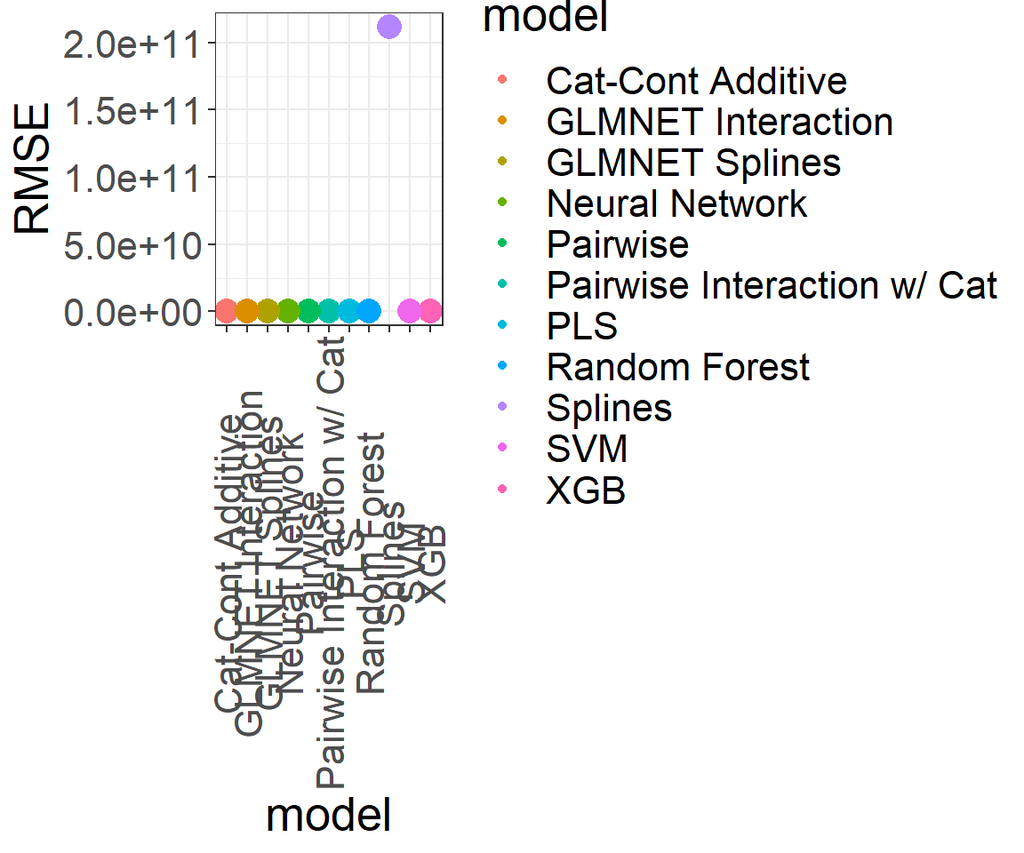

```r
sort_results %>%
  ggplot(mapping = aes(x = model, y = RMSE)) +
  geom_point(mapping = aes(color = model, size = 5)) +
  theme_bw() +
  theme(text = element_text(size = 20), axis.text.x = element_text(angle = 90, vjust = 0.5))
```

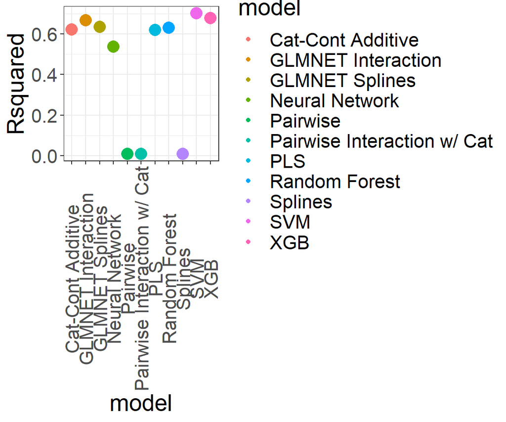

```r
sort_results %>%
  ggplot(mapping = aes(x = model, y = Rsquared)) +
  geom_point(mapping = aes(color = model, size = 5)) +
  theme_bw()  +
  theme(text = element_text(size = 20), axis.text.x = element_text(angle = 90, vjust = 0.5))
```

A few of these models are clearly superfluous, we should get a better look at our best performing models by pruning our set of those models which are not performing well in comparison.

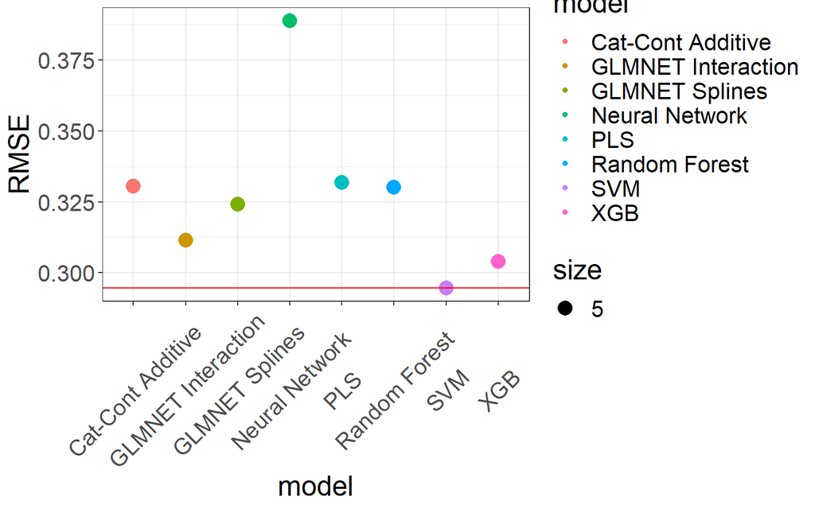

```r
sort_results %>% filter(RMSE < 0.7) %>%
  ggplot(mapping = aes(x = model, y = RMSE)) +
  geom_point(mapping = aes(color = model, size = 5)) +
  theme_bw() +
  theme(text = element_text(size = 20), axis.text.x = element_text(angle = 45, vjust = 0.5)) + geom_hline(yintercept = mod_10_RMSE, color = 'red')
```

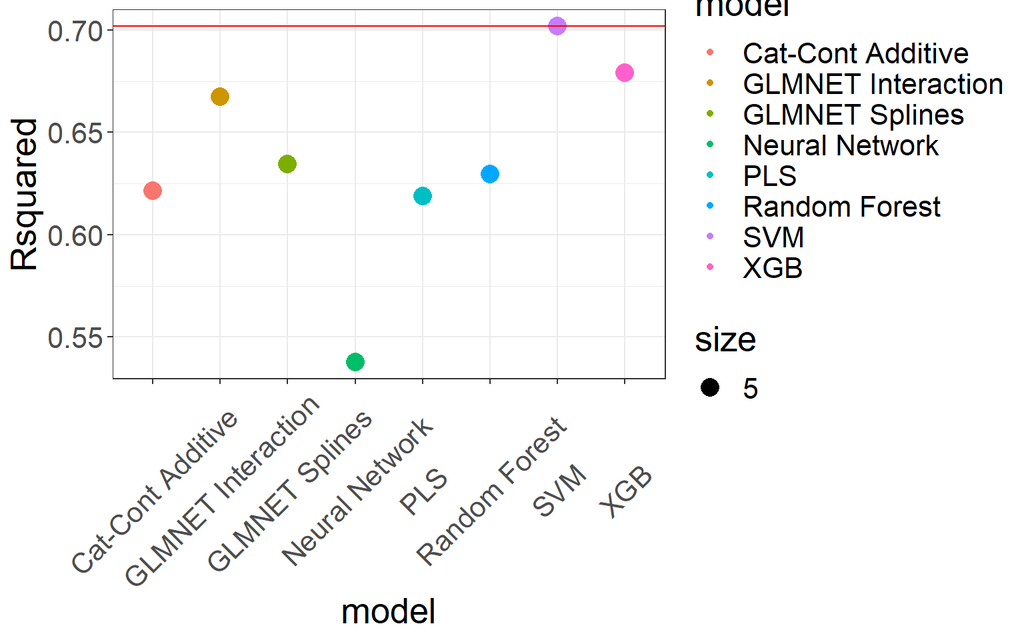

```r
sort_results %>% filter(Rsquared > 0.3) %>%
  ggplot(mapping = aes(x = model, y = Rsquared)) +
  geom_point(mapping = aes(color = model, size = 5)) +
  theme_bw()  +
  theme(text = element_text(size = 20), axis.text.x = element_text(angle = 45, vjust = 0.5)) + geom_hline(yintercept = mod_10_R2, color = 'red')
```

Best Model:

Based on the performance metrics of R-squared and RMSE, the best overall model at the current time is the Support Vector Machine

###CLASSIFICATION

#TRAIN CONTROL

```r
ctrl_acc <- trainControl(method = "repeatedcv",
                         number = 10,
                         repeats = 3,
                         savePredictions = TRUE)

metric_acc <- "Accuracy"


ctrl_roc <- trainControl(method = "repeatedcv",
                         number = 5,
                         repeats = 5,
                         summaryFunction = twoClassSummary,
                         classProbs = TRUE,
                         savePredictions = TRUE)

metric_roc <- "ROC"
```

##LINEAR

```r
mod1_acc <- train(  outcome ~ xa_01 +
                       xa_02 + xa_03 + xa_04 + xa_05 + xa_06 + xa_07 + xa_08 +
                       xb_01 + xb_02 +  xb_03 + xb_04 + xb_05 + xb_06 +  xb_07 + xb_08 +
                       xs_01 + xs_02 + xs_03 + xs_04 + xs_05 + xs_06 +
                       xn_01 + xn_02 + xn_03 + xn_04 + xn_05 + xn_06 + xn_07 + xn_08 +
                       xw_01 + xw_02 + xw_03,
                     data = df_all,
                     method = "glm",
                     metric = metric_acc,
                     preProcess = c("center", "scale"),
                     trControl = ctrl_acc)

mod1_roc <- train(  outcome ~ xa_01 +
                       xa_02 + xa_03 + xa_04 + xa_05 + xa_06 + xa_07 + xa_08 +
                       xb_01 + xb_02 +  xb_03 + xb_04 + xb_05 + xb_06 +  xb_07 + xb_08 +
                       xs_01 + xs_02 + xs_03 + xs_04 + xs_05 + xs_06 +
                       xn_01 + xn_02 + xn_03 + xn_04 + xn_05 + xn_06 + xn_07 + xn_08 +
                       xw_01 + xw_02 + xw_03,
                     data = df_all,
                     method = "glm",
                     metric = metric_roc,
                     preProcess = c("center", "scale"),
                     trControl = ctrl_roc)
```

#Model 2: Linear Pairwise of Continuous w/ Additive Categorical

```r
mod2_acc <- train(outcome ~ (xa_01 + xa_02 + xa_03 + xa_04 + xa_05 + xa_06 + xa_07 + xa_08 +
              xb_01 + xb_02 +  xb_03 + xb_04 + xb_05 + xb_06 +  xb_07 + xb_08 +
              xs_01 + xs_02 + xs_03 + xs_04 + xs_05 + xs_06 +
              xn_01 + xn_02 + xn_03 + xn_04 + xn_05 + xn_06 + xn_07 + xn_08 +
              xw_01 + xw_02 + xw_03)^2 + region_XX + region_YY + region_ZZ + customer_A +
                customer_B + customer_D + customer_E + customer_G + customer_K + customer_M +
              customer_Other + customer_Q,
                  data = df_all,
                  method = "glm",
                  metric = metric_acc,
                  preProcess = c("center", "scale"),
                  trControl = ctrl_acc)

mod2_roc <- train(outcome ~ (xa_01 + xa_02 + xa_03 + xa_04 + xa_05 + xa_06 + xa_07 + xa_08 +
              xb_01 + xb_02 +  xb_03 + xb_04 + xb_05 + xb_06 +  xb_07 + xb_08 +
              xs_01 + xs_02 + xs_03 + xs_04 + xs_05 + xs_06 +
              xn_01 + xn_02 + xn_03 + xn_04 + xn_05 + xn_06 + xn_07 + xn_08 +
              xw_01 + xw_02 + xw_03)^2 + region_XX + region_YY + region_ZZ + customer_A +
                customer_B + customer_D + customer_E + customer_G + customer_K + customer_M +
              customer_Other + customer_Q,
                  data = df_all,
                  method = "glm",
                  metric = metric_roc,
                  preProcess = c("center", "scale"),
                  trControl = ctrl_roc)
```

#Model 3: Model A

```r
mod3_acc <- train(outcome ~
              (xa_01 + xa_02 + xa_03 + xa_04 + xa_05 + xa_06 + xa_07 + xa_08) *
  (region_XX + region_YY + region_ZZ) +
              (xb_01 + xb_02 +  xb_03 + xb_04 + xb_05 + xb_06 +  xb_07 + xb_08) *
  (region_XX + region_YY + region_ZZ) +
              (xs_01 + xs_02 + xs_03 + xs_04 + xs_05 + xs_06)*
  (region_XX + region_YY + region_ZZ) +
              (xn_01 + xn_02 + xn_03 + xn_04 + xn_05 + xn_06 + xn_07 + xn_08)*
  (region_XX + region_YY + region_ZZ) +
              (xw_01 + xw_02 + xw_03)*
  (region_XX + region_YY + region_ZZ),
  data = df_all,
  method = "glm",
  metric = metric_acc,
  preProcess = c("center", "scale"),
  trControl = ctrl_acc)

mod3_roc <- train(outcome ~
              (xa_01 + xa_02 + xa_03 + xa_04 + xa_05 + xa_06 + xa_07 + xa_08) *
  (region_XX + region_YY + region_ZZ) +
              (xb_01 + xb_02 +  xb_03 + xb_04 + xb_05 + xb_06 +  xb_07 + xb_08) *
  (region_XX + region_YY + region_ZZ) +
              (xs_01 + xs_02 + xs_03 + xs_04 + xs_05 + xs_06)*
  (region_XX + region_YY + region_ZZ) +
              (xn_01 + xn_02 + xn_03 + xn_04 + xn_05 + xn_06 + xn_07 + xn_08)*
  (region_XX + region_YY + region_ZZ) +
              (xw_01 + xw_02 + xw_03)*
  (region_XX + region_YY + region_ZZ),
  data = df_all,
  method = "glm",
  metric = metric_roc,
  preProcess = c("center", "scale"),
  trControl = ctrl_roc)
```

#Model 4: Model B

```r
mod4_acc <- train(outcome ~
              splines::ns(xa_01, 2) + splines::ns(xa_02, 2) + splines::ns(xa_03, 2) + splines::ns(xa_04, 2) +
              splines::ns(xa_05, 2) + splines::ns(xa_06, 2) + splines::ns(xa_07, 2) + splines::ns(xa_08, 2) +

              splines::ns(xb_01, 2) + splines::ns(xb_02, 2) + splines::ns(xb_03, 2) + splines::ns(xb_04, 2) +
              splines::ns(xb_05, 2) + splines::ns(xb_06, 2) + splines::ns(xb_07, 2) + splines::ns(xb_08, 2) +

              splines::ns(xs_01, 2) + splines::ns(xs_02, 2) + splines::ns(xs_03, 2) + splines::ns(xs_04, 2) +
              splines::ns(xs_05, 2) + splines::ns(xs_06, 2) +

              splines::ns(xn_01, 2) + splines::ns(xn_02, 2) + splines::ns(xn_03, 2) + splines::ns(xn_04, 2) +
              splines::ns(xn_05, 2) + splines::ns(xn_06, 2) + splines::ns(xn_07, 2) + splines::ns(xn_08, 2) +

              splines::ns(xw_01, 2) + splines::ns(xw_02, 2) + splines::ns(xw_03, 2),
  data = df_all,
  method = "glm",
  metric = metric_acc,
  preProcess = c("center", "scale"),
  trControl = ctrl_acc)

mod4_roc <- train(outcome ~
              splines::ns(xa_01, 2) + splines::ns(xa_02, 2) + splines::ns(xa_03, 2) + splines::ns(xa_04, 2) +
              splines::ns(xa_05, 2) + splines::ns(xa_06, 2) + splines::ns(xa_07, 2) + splines::ns(xa_08, 2) +

              splines::ns(xb_01, 2) + splines::ns(xb_02, 2) + splines::ns(xb_03, 2) + splines::ns(xb_04, 2) +
              splines::ns(xb_05, 2) + splines::ns(xb_06, 2) + splines::ns(xb_07, 2) + splines::ns(xb_08, 2) +

              splines::ns(xs_01, 2) + splines::ns(xs_02, 2) + splines::ns(xs_03, 2) + splines::ns(xs_04, 2) +
              splines::ns(xs_05, 2) + splines::ns(xs_06, 2) +

              splines::ns(xn_01, 2) + splines::ns(xn_02, 2) + splines::ns(xn_03, 2) + splines::ns(xn_04, 2) +
              splines::ns(xn_05, 2) + splines::ns(xn_06, 2) + splines::ns(xn_07, 2) + splines::ns(xn_08, 2) +

              splines::ns(xw_01, 2) + splines::ns(xw_02, 2) + splines::ns(xw_03, 2),
  data = df_all,
  method = "glm",
  metric = metric_roc,
  preProcess = c("center", "scale"),
  trControl = ctrl_roc)
```

##REGULARIZED REGRESSION W/ ELASTIC NET

#Model 5: Pairwise of Continuous w/ Additive Categorical

```r
mod5_acc <- train(outcome ~
              (xa_01 + xa_02 + xa_03 + xa_04 + xa_05 + xa_06 + xa_07 +
                     xa_08 + xb_01 + xb_02 +  xb_03 + xb_04 + xb_05 + xb_06 +  xb_07 + xb_08 +
                     xs_01 + xs_02 + xs_03 + xs_04 + xs_05 + xs_06 +
                     xn_01 + xn_02 + xn_03 + xn_04 + xn_05 + xn_06 + xn_07 + xn_08 +
                     xw_01 + xw_02 + xw_03)^2 + region_XX + region_YY + region_ZZ +
                     customer_A + customer_B + customer_D + customer_E + customer_G +
                     customer_K + customer_M + customer_Other + customer_Q, data = df_all,
                  method = "glmnet",
                  metric = metric_acc,
                  preProcess = c("center", "scale"),
                  trControl = ctrl_acc)

mod5_roc <- train(outcome ~
              (xa_01 + xa_02 + xa_03 + xa_04 + xa_05 + xa_06 + xa_07 +
                     xa_08 + xb_01 + xb_02 +  xb_03 + xb_04 + xb_05 + xb_06 +  xb_07 + xb_08 +
                     xs_01 + xs_02 + xs_03 + xs_04 + xs_05 + xs_06 +
                     xn_01 + xn_02 + xn_03 + xn_04 + xn_05 + xn_06 + xn_07 + xn_08 +
                     xw_01 + xw_02 + xw_03)^2 + region_XX + region_YY + region_ZZ +
                     customer_A + customer_B + customer_D + customer_E + customer_G +
                     customer_K + customer_M + customer_Other + customer_Q, data = df_all,
                  method = "glmnet",
                  metric = metric_roc,
                  preProcess = c("center", "scale"),
                  trControl = ctrl_roc)
```

#Model 6: Complex Model A

```r
mod6_acc <- train(outcome ~
              splines::ns(xa_01, 2) + splines::ns(xa_02, 2) + splines::ns(xa_03, 2) + splines::ns(xa_04, 2) +
              splines::ns(xa_05, 2) + splines::ns(xa_06, 2) + splines::ns(xa_07, 2) + splines::ns(xa_08, 2) +

              splines::ns(xb_01, 2) + splines::ns(xb_02, 2) + splines::ns(xb_03, 2) + splines::ns(xb_04, 2) +
              splines::ns(xb_05, 2) + splines::ns(xb_06, 2) + splines::ns(xb_07, 2) + splines::ns(xb_08, 2) +

              splines::ns(xs_01, 2) + splines::ns(xs_02, 2) + splines::ns(xs_03, 2) + splines::ns(xs_04, 2) +
              splines::ns(xs_05, 2) + splines::ns(xs_06, 2) +

              splines::ns(xn_01, 2) + splines::ns(xn_02, 2) + splines::ns(xn_03, 2) + splines::ns(xn_04, 2) +
              splines::ns(xn_05, 2) + splines::ns(xn_06, 2) + splines::ns(xn_07, 2) + splines::ns(xn_08, 2) +

              splines::ns(xw_01, 2) + splines::ns(xw_02, 2) + splines::ns(xw_03, 2),
  data = df_all,
  method = "glmnet",
  metric = metric_acc,
  preProcess = c("center", "scale"),
  trControl = ctrl_acc)

mod6_roc <- train(outcome ~
              splines::ns(xa_01, 2) + splines::ns(xa_02, 2) + splines::ns(xa_03, 2) + splines::ns(xa_04, 2) +
              splines::ns(xa_05, 2) + splines::ns(xa_06, 2) + splines::ns(xa_07, 2) + splines::ns(xa_08, 2) +

              splines::ns(xb_01, 2) + splines::ns(xb_02, 2) + splines::ns(xb_03, 2) + splines::ns(xb_04, 2) +
              splines::ns(xb_05, 2) + splines::ns(xb_06, 2) + splines::ns(xb_07, 2) + splines::ns(xb_08, 2) +

              splines::ns(xs_01, 2) + splines::ns(xs_02, 2) + splines::ns(xs_03, 2) + splines::ns(xs_04, 2) +
              splines::ns(xs_05, 2) + splines::ns(xs_06, 2) +

              splines::ns(xn_01, 2) + splines::ns(xn_02, 2) + splines::ns(xn_03, 2) + splines::ns(xn_04, 2) +
              splines::ns(xn_05, 2) + splines::ns(xn_06, 2) + splines::ns(xn_07, 2) + splines::ns(xn_08, 2) +

              splines::ns(xw_01, 2) + splines::ns(xw_02, 2) + splines::ns(xw_03, 2),
  data = df_all,
  method = "glmnet",
  metric = metric_roc,
  preProcess = c("center", "scale"),
  trControl = ctrl_roc)
```

#Model 7: Neural Network

```r
mod7_acc <- train(outcome ~
                    xa_01 + xa_02 + xa_03 + xa_04 + xa_05 + xa_06 + xa_07 + xa_08 +
              xb_01 + xb_02 +  xb_03 + xb_04 + xb_05 + xb_06 +  xb_07 + xb_08 +
              xs_01 + xs_02 + xs_03 + xs_04 + xs_05 + xs_06 +
              xn_01 + xn_02 + xn_03 + xn_04 + xn_05 + xn_06 + xn_07 + xn_08 +
              xw_01 + xw_02 + xw_03 + region_XX + region_YY + region_ZZ +
                customer_A + customer_B + customer_D + customer_E + customer_G +
                customer_K + customer_M +  customer_Other + customer_Q , data = df_all,
                  method = "nnet",
                  metric = metric_acc,
                  preProcess = c("center", "scale"),
                  trControl = ctrl_acc,
              trace = 0)

mod7_roc <- train(outcome ~
                    xa_01 + xa_02 + xa_03 + xa_04 + xa_05 + xa_06 + xa_07 + xa_08 +
              xb_01 + xb_02 +  xb_03 + xb_04 + xb_05 + xb_06 +  xb_07 + xb_08 +
              xs_01 + xs_02 + xs_03 + xs_04 + xs_05 + xs_06 +
              xn_01 + xn_02 + xn_03 + xn_04 + xn_05 + xn_06 + xn_07 + xn_08 +
              xw_01 + xw_02 + xw_03 + region_XX + region_YY + region_ZZ +
                customer_A + customer_B + customer_D + customer_E + customer_G +
                customer_K + customer_M +  customer_Other + customer_Q , data = df_all,
                  method = "nnet",
                  metric = metric_roc,
                  preProcess = c("center", "scale"),
                  trControl = ctrl_roc,
              trace = 0)
```

#Model 8: Random Forest

```r
set.seed(12345)
my_ctrl_rf <- caret::trainControl(method = "cv",
                               number = 3,
                               savePredictions = TRUE,
                               search = 'random')

mod8_acc <- train(outcome ~
                    xa_01 + xa_02 + xa_03 + xa_04 + xa_05 + xa_06 + xa_07 + xa_08 +
              xb_01 + xb_02 +  xb_03 + xb_04 + xb_05 + xb_06 +  xb_07 + xb_08 +
              xs_01 + xs_02 + xs_03 + xs_04 + xs_05 + xs_06 +
              xn_01 + xn_02 + xn_03 + xn_04 + xn_05 + xn_06 + xn_07 + xn_08 +
              xw_01 + xw_02 + xw_03 + region_XX + region_YY + region_ZZ +
                customer_A + customer_B + customer_D + customer_E + customer_G +
                customer_K + customer_M +  customer_Other + customer_Q ,
                   data = df_all,
                   method = 'rf',
                   metric = metric_acc,
                   tuneLength  = 15,
                   trControl = my_ctrl_rf,
              trace = FALSE)

mod8_roc <- train(outcome ~
                    xa_01 + xa_02 + xa_03 + xa_04 + xa_05 + xa_06 + xa_07 + xa_08 +
              xb_01 + xb_02 +  xb_03 + xb_04 + xb_05 + xb_06 +  xb_07 + xb_08 +
              xs_01 + xs_02 + xs_03 + xs_04 + xs_05 + xs_06 +
              xn_01 + xn_02 + xn_03 + xn_04 + xn_05 + xn_06 + xn_07 + xn_08 +
              xw_01 + xw_02 + xw_03 + region_XX + region_YY + region_ZZ +
                customer_A + customer_B + customer_D + customer_E + customer_G +
                customer_K + customer_M +  customer_Other + customer_Q ,
                   data = df_all,
                   method = 'rf',
                   metric = metric_roc,
                   tuneLength  = 15,
                   trControl = ctrl_roc,
              trace = FALSE)
```

#Model 9: Gradient Boosted Tree

```r
#FIT FOR ACCURACY
fit_xgb <- train(outcome ~ region_XX + region_YY + region_ZZ +
              customer_A + customer_B + customer_D + customer_E + customer_G + customer_K + customer_M +  customer_Other + customer_Q +
              xa_01 + xa_02 + xa_03 + xa_04 + xa_05 + xa_06 + xa_07 + xa_08 +
              xb_01 + xb_02 +  xb_03 + xb_04 + xb_05 + xb_06 +  xb_07 + xb_08 +
              xs_01 + xs_02 + xs_03 + xs_04 + xs_05 + xs_06 +
              xn_01 + xn_02 + xn_03 + xn_04 + xn_05 + xn_06 + xn_07 + xn_08 +
              xw_01 + xw_02 + xw_03,
              data = df_all,
              method = "xgbTree",
              metric = metric_acc,
              trControl = ctrl_acc,
              objective = 'reg:squarederror',
              trace = 0)
```

[output not shown]

[output cut: 10751 more lines]

[output not shown]

```r
xgb_grid <- expand.grid(nrounds = seq(100, 700, by = 100),
                        max_depth = c(3, 4, 5),
                        eta = c(0.5*fit_xgb$bestTune$eta, fit_xgb$bestTune$eta),
                        gamma = fit_xgb$bestTune$gamma,
                        colsample_bytree = fit_xgb$bestTune$colsample_bytree,
                        min_child_weight = fit_xgb$bestTune$min_child_weight,
                        subsample = fit_xgb$bestTune$subsample)

mod9_acc <- train(outcome ~ region_XX + region_YY + region_ZZ +
              customer_A + customer_B + customer_D + customer_E + customer_G + customer_K + customer_M +  customer_Other + customer_Q +
              xa_01 + xa_02 + xa_03 + xa_04 + xa_05 + xa_06 + xa_07 + xa_08 +
              xb_01 + xb_02 +  xb_03 + xb_04 + xb_05 + xb_06 +  xb_07 + xb_08 +
              xs_01 + xs_02 + xs_03 + xs_04 + xs_05 + xs_06 +
              xn_01 + xn_02 + xn_03 + xn_04 + xn_05 + xn_06 + xn_07 + xn_08 +
              xw_01 + xw_02 + xw_03,
              data = df_all,
              tuneGrid = xgb_grid,
              method = "xgbTree",
              metric = metric_acc,
              trControl = ctrl_acc,
              objective = 'reg:squarederror',
              trace = 0)
```

[output not shown]

[output cut: 2471 more lines]

[output not shown]

```r
# FIT FOR ROC

fit_xgb <- train(outcome ~ region_XX + region_YY + region_ZZ +
              customer_A + customer_B + customer_D + customer_E + customer_G + customer_K + customer_M +  customer_Other + customer_Q +
              xa_01 + xa_02 + xa_03 + xa_04 + xa_05 + xa_06 + xa_07 + xa_08 +
              xb_01 + xb_02 +  xb_03 + xb_04 + xb_05 + xb_06 +  xb_07 + xb_08 +
              xs_01 + xs_02 + xs_03 + xs_04 + xs_05 + xs_06 +
              xn_01 + xn_02 + xn_03 + xn_04 + xn_05 + xn_06 + xn_07 + xn_08 +
              xw_01 + xw_02 + xw_03,
              data = df_all,
              method = "xgbTree",
              metric = metric_acc,
              trControl = ctrl_acc,
              objective = 'reg:squarederror',
              trace = 0)
```

[output not shown]

[output cut: 10751 more lines]

[output not shown]

```r
xgb_grid <- expand.grid(nrounds = seq(100, 700, by = 100),
                        max_depth = c(3, 4, 5),
                        eta = c(0.5*fit_xgb$bestTune$eta, fit_xgb$bestTune$eta),
                        gamma = fit_xgb$bestTune$gamma,
                        colsample_bytree = fit_xgb$bestTune$colsample_bytree,
                        min_child_weight = fit_xgb$bestTune$min_child_weight,
                        subsample = fit_xgb$bestTune$subsample)

mod9_roc <- train(outcome ~ region_XX + region_YY + region_ZZ +
              customer_A + customer_B + customer_D + customer_E + customer_G + customer_K + customer_M +  customer_Other + customer_Q +
              xa_01 + xa_02 + xa_03 + xa_04 + xa_05 + xa_06 + xa_07 + xa_08 +
              xb_01 + xb_02 +  xb_03 + xb_04 + xb_05 + xb_06 +  xb_07 + xb_08 +
              xs_01 + xs_02 + xs_03 + xs_04 + xs_05 + xs_06 +
              xn_01 + xn_02 + xn_03 + xn_04 + xn_05 + xn_06 + xn_07 + xn_08 +
              xw_01 + xw_02 + xw_03,
              data = df_all,
              tuneGrid = xgb_grid,
              method = "xgbTree",
              metric = metric_roc,
              trControl = ctrl_roc,
              objective = 'reg:squarederror',
              trace = 0)
```

[output not shown]

[output cut: 2951 more lines]

[output not shown]

#Model 10:

```r
#choices: SVM, Naive Bayes, GAM, MARS, PLS, Deep Neural Network, K-nearest neighbors
mod10_acc <- train(outcome ~ region_XX + region_YY + region_ZZ +
              customer_A + customer_B + customer_D + customer_E + customer_G +
              customer_K + customer_M +  customer_Other + customer_Q +
              xa_01 + xa_02 + xa_03 + xa_04 + xa_05 + xa_06 + xa_07 + xa_08 +
              xb_01 + xb_02 +  xb_03 + xb_04 + xb_05 + xb_06 +  xb_07 + xb_08 +
              xs_01 + xs_02 + xs_03 + xs_04 + xs_05 + xs_06 +
              xn_01 + xn_02 + xn_03 + xn_04 + xn_05 + xn_06 + xn_07 + xn_08 +
              xw_01 + xw_02 + xw_03,
              data = df_all,
              method = "svmRadial",
              metric = metric_acc,
              preProcess = c("center", "scale"),
              trControl = ctrl_acc)

mod10_roc <- train(outcome ~ region_XX + region_YY + region_ZZ +
              customer_A + customer_B + customer_D + customer_E + customer_G +
              customer_K + customer_M +  customer_Other + customer_Q +
              xa_01 + xa_02 + xa_03 + xa_04 + xa_05 + xa_06 + xa_07 + xa_08 +
              xb_01 + xb_02 +  xb_03 + xb_04 + xb_05 + xb_06 +  xb_07 + xb_08 +
              xs_01 + xs_02 + xs_03 + xs_04 + xs_05 + xs_06 +
              xn_01 + xn_02 + xn_03 + xn_04 + xn_05 + xn_06 + xn_07 + xn_08 +
              xw_01 + xw_02 + xw_03,
              data = df_all,
              method = "svmRadial",
              metric = metric_roc,
              preProcess = c("center", "scale"),
              trControl = ctrl_roc)
```

#Model 11:

```r
pls_grid <- expand.grid(ncomp = 1:5)


mod11_acc <- train(outcome ~ region_XX + region_YY + region_ZZ +
              customer_A + customer_B + customer_D + customer_E + customer_G +
              customer_K + customer_M +  customer_Other + customer_Q +
              xa_01 + xa_02 + xa_03 + xa_04 + xa_05 + xa_06 + xa_07 + xa_08 +
              xb_01 + xb_02 +  xb_03 + xb_04 + xb_05 + xb_06 +  xb_07 + xb_08 +
              xs_01 + xs_02 + xs_03 + xs_04 + xs_05 + xs_06 +
              xn_01 + xn_02 + xn_03 + xn_04 + xn_05 + xn_06 + xn_07 + xn_08 +
              xw_01 + xw_02 + xw_03,
              data = df_all,
              method = "pls",
              metric = metric_acc,
              tuneGrid = pls_grid,
              preProcess = c("center", "scale"),
              trControl = ctrl_acc)

mod11_roc <- train(outcome ~ region_XX + region_YY + region_ZZ +
              customer_A + customer_B + customer_D + customer_E + customer_G +
              customer_K + customer_M +  customer_Other + customer_Q +
              xa_01 + xa_02 + xa_03 + xa_04 + xa_05 + xa_06 + xa_07 + xa_08 +
              xb_01 + xb_02 +  xb_03 + xb_04 + xb_05 + xb_06 +  xb_07 + xb_08 +
              xs_01 + xs_02 + xs_03 + xs_04 + xs_05 + xs_06 +
              xn_01 + xn_02 + xn_03 + xn_04 + xn_05 + xn_06 + xn_07 + xn_08 +
              xw_01 + xw_02 + xw_03,
              data = df_all,
              method = "pls",
              metric = metric_roc,
              tuneGrid = pls_grid,
              preProcess = c("center", "scale"),
              trControl = ctrl_roc)
```

#Model Evaluation

```r
mod_1_accuracy <- min(mod1_acc$results['Accuracy'])
mod_2_accuracy <- min(mod2_acc$results['Accuracy'])
mod_3_accuracy <- min(mod3_acc$results['Accuracy'])
mod_4_accuracy <- min(mod4_acc$results['Accuracy'])
mod_5_accuracy <- min(mod5_acc$results['Accuracy'])
mod_6_accuracy <- min(mod6_acc$results['Accuracy'])
mod_7_accuracy <- min(mod7_acc$results['Accuracy'])
mod_8_accuracy <- min(mod8_acc$results['Accuracy'])
mod_9_accuracy <- min(mod9_acc$results['Accuracy'])
mod_10_accuracy<- min(mod10_acc$results['Accuracy'])
mod_11_accuracy<- min(mod11_acc$results['Accuracy'])

mod_1_roc <- min(mod1_roc$results['ROC'])
mod_2_roc <- min(mod2_roc$results['ROC'])
mod_3_roc <- min(mod3_roc$results['ROC'])
mod_4_roc <- min(mod4_roc$results['ROC'])
mod_5_roc <- min(mod5_roc$results['ROC'])
mod_6_roc <- min(mod6_roc$results['ROC'])
mod_7_roc <- min(mod7_roc$results['ROC'])
mod_8_roc <- min(mod8_roc$results['ROC'])
mod_9_roc <- min(mod9_roc$results['ROC'])
mod_10_roc<- min(mod10_roc$results['ROC'])
mod_11_roc<- min(mod11_roc$results['ROC'])


results <- tibble(Accuracy = c(mod_1_accuracy, mod_2_accuracy, mod_3_accuracy, mod_4_accuracy, mod_5_accuracy, mod_6_accuracy, mod_7_accuracy, mod_8_accuracy, mod_9_accuracy, mod_10_accuracy,mod_11_accuracy),
                  ROC = c(mod_1_roc, mod_2_roc, mod_3_roc, mod_4_roc, mod_5_roc, mod_6_roc, mod_7_roc, mod_8_roc, mod_9_roc, mod_10_roc, mod_11_roc),
                  model = c("Catagorical-Continuous Additive", "Pairwise Interaction w/ Catagorical", "Splines:Regions", "Splines", "GLMNET Pairwise Interaction", "GLMNET Splines", "Neural Network", "Random Forest", "XGB", "SVM", "PLS"))





sort_acc_results <- results %>% arrange(desc(Accuracy))
sort_roc_results <- results %>% arrange(desc(ROC))
```

Plotting results

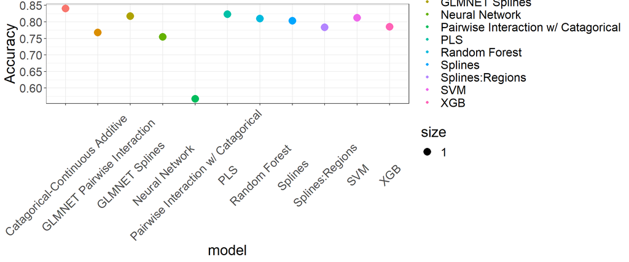

```r
sort_acc_results %>%
  ggplot(mapping = aes(x = model, y = Accuracy)) +
  geom_point(mapping = aes(color = model, size = 1)) +
  theme_bw() +
  theme(text = element_text(size = 20), axis.text.x = element_text(angle = 45, vjust = 0.5))
```

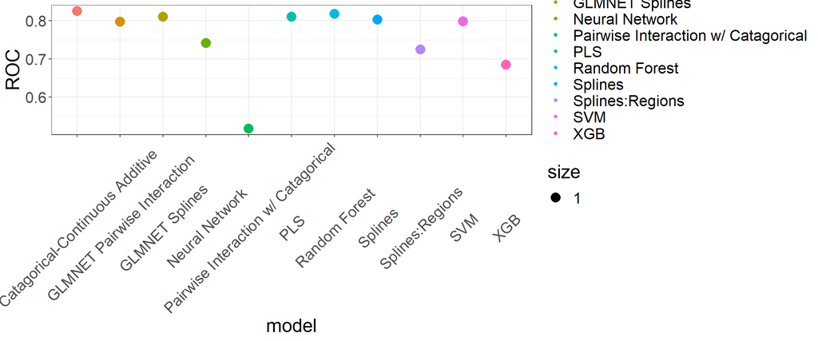

```r
sort_roc_results %>%
  ggplot(mapping = aes(x = model, y = ROC)) +
  geom_point(mapping = aes(color = model, size = 1)) +
  theme_bw()  +
  theme(text = element_text(size = 20), axis.text.x = element_text(angle = 45, vjust = 0.5))
```

A few of these models are clearly superfluous, we should get a better look at our best performing models by pruning our set of those models which are not performing well in comparison.

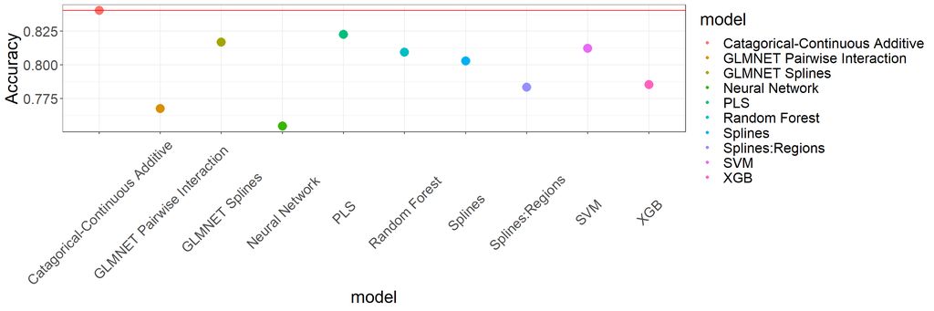

```r
sort_acc_results %>% filter(Accuracy > 0.75) %>%
  ggplot(mapping = aes(x = model, y = Accuracy)) +
  geom_point(mapping = aes(color = model, size = 3)) +
  theme_bw() +
  theme(text = element_text(size = 20), axis.text.x = element_text(angle = 45, vjust = 0.5)) + geom_hline(yintercept = mod_1_accuracy, color = 'red')
```

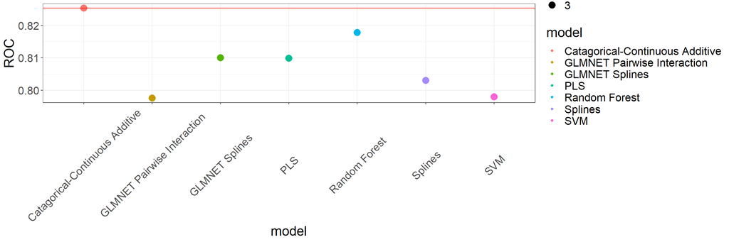

```r
sort_roc_results %>% filter(ROC > 0.75) %>%
  ggplot(mapping = aes(x = model, y = ROC)) +
  geom_point(mapping = aes(color = model, size = 3)) +
  theme_bw()  +
  theme(text = element_text(size = 20), axis.text.x = element_text(angle = 45, vjust = 0.5)) + geom_hline(yintercept = mod_1_roc, color = 'red' )
```